# CMDA-3654

Homework 5

Eduardo Salvador

Due as a .pdf upload

# Instructions:

**Delete the Instructions section from your write-up!!**

I have given you this assignment as an .Rmd (R Markdown) file.

- Change the name of the file to: `Lastname_Firstname_CMDA_3654_HW5.Rmd`, and your output should therefore match but with a `.pdf` extension.
- You need to edit the R Markdown file by filling in the chunks appropriately with your code. Output will be generated automatically when you compile the document.
- You also need to add your own text before and after the chunks to explain what you are doing or to interpret the output.
- Feel free to add additional chunks if needed. I **will not** be providing assignments to you like this for the entire semester, just long enough for you to learn how to do it for yourself.

**Required: The final product that you turn in must be a .pdf file.**

- You MUST Knit this document directly to a PDF conversion from another format is not permitted.

# Problem 1: [50 pts] Tidying Data with `dplyr`

## Unicorns on unicycles

This dataset is thought to have been recorded by an amateur scientist, a natural philosopher by the name of Rudolphus in the 17th century in The Netherlands. This scientist recorded the annual population of unicorns in western Europe over a century and also recorded the sales of unicycles in that same time period. Although not much of the accompanying text remains of the original documents, what we can read is the tables and the idea that Rudolphus thought there was some sort of relationship between uncorns and unicycle sales.

The documents were recently unearthed from a hidden chest in Delft and seem to be written by Rudolphus Hogervorstus, my great great great uncle, in 1681. These documents show that he was studying the then roaming herds of unicorns in the area around Delft. Unfortunately these animals are extinct now.

His work contains multiple tables, carefully written down, documenting the population of unicorns over time in multiple places and related to that the sales and numbers of unicycles in those countries.

There are also some text describing the hypotheses of Rudolphus, but most of the texts were eaten by moths and have decayed over time. Some of the remaining text suggest that, according to Rudolphus, the unicorn populations and unicycles were related: “The presence of the cone on the unicorn hints at a very defined sense of equilibrium, …[some missing text]….. it is therefore only natural to assume unicorns ride unicycles”.

### Your task

We want to discover the relationship between unicorns and unicycles. As part of the archival process these tables were copied in excel.

Try to read the data in, if you are using R, try the package `readxl`. It also helps if you look at the data before reading it in.

Load the two files, try to join them together.

Is there a relation between unicorns and unicycles?

### About the data

Consider the `sales.xlsx` and `observations.xlsx` data sets.

- `observations.xlsx` contains information about the population of unicorns for specific years different countries.
- `sales.xlsx` contains two tables one of them consists of the total number of unicycles sold. The other is the revenue from the unicycle sales.

### Problem Instructions

1. Join the two files together to create a single data frame, called `unicorns.cycling`. (Be sure to take precautions concerning country names being slightly different in the two files). Create a “tidy” data frame with appropriately named variables. (i.e. country, year, variable1, variable2, etc). Display the first 10 rows of the final data frame.

```r
library(tidyverse)
library(readxl)
library(dplyr)
#Bring up Excel files using read_xlsx
obs <- read_xlsx("/Users/eduardosalvador/Desktop/FINAL\ Spring\ Semester\ 2021/CMDA\ /Assignments/HW5/observations.xlsx")
sales <- read_xlsx("/Users/eduardosalvador/Desktop/FINAL\ Spring\ Semester\ 2021/CMDA\ /Assignments/HW5/sales.xlsx")
#Selected colums 6 to 8 for turnover and 1 to 3 for sales
total_turnover <- select(sales,6:8)
unicycle <- select(sales,1:3)
#Set up to be able to merge
names(unicycle)[1] <- "countryname"
names(unicycle)[2] <- "year"
names(total_turnover)[1] <- "countryname"
names(total_turnover)[2] <- "year"
#Merging dataframe by countryname and year in sales
sales <- merge(total_turnover,unicycle,by = c("countryname","year"),all.x=T)
#Getting population observations
obs$countryname <- toupper(obs$countryname)
#Displaying first 10 rows of dataframe by left join sales and observations
unicorns.cycling<-left_join(sales,obs)
unicorns.cycling[1:10,]
```

|  | countryname | year | total_turnover | unicycles | pop |
| --- | --- | --- | --- | --- | --- |
| 1 | AUSTRIA | 1670 | 5274.0 | 60 | 85 |
| 2 | AUSTRIA | 1671 | 5186.1 | 59 | 83 |
| 3 | AUSTRIA | 1674 | 4658.7 | 53 | 75 |
| 4 | AUSTRIA | 1675 | 5098.2 | 58 | 82 |
| 5 | AUSTRIA | 1676 | 4922.4 | 56 | 79 |
| 6 | AUSTRIA | 1677 | 4395.0 | 50 | 70 |
| 7 | AUSTRIA | 1678 | 5010.3 | 57 | 81 |
| 8 | AUSTRIA | 1680 | 5010.3 | 57 | 80 |
| 9 | FRANCE | 1673 | 4321.8 | 49 | 70 |
| 10 | FRANCE | 1674 | 4939.2 | 56 | 79 |

2. Report a summary table of this new “tidy” data frame.

```r
#Used summary function
summary(unicorns.cycling)
```

```
 countryname             year      total_turnover   unicycles
 Length:42          Min.   :1670   Min.   :3758   Min.   :44.00
 Class :character   1st Qu.:1673   1st Qu.:4663   1st Qu.:53.00
 Mode  :character   Median :1676   Median :4938   Median :56.00
                    Mean   :1676   Mean   :4989   Mean   :57.29
                    3rd Qu.:1678   3rd Qu.:5288   3rd Qu.:60.00
                    Max.   :1680   Max.   :6380   Max.   :73.00
      pop
 Min.   : 63.00
 1st Qu.: 75.25
 Median : 80.00
 Mean   : 81.71
 3rd Qu.: 86.50
 Max.   :104.00
```

3. Use `dplyr`, create new variables that calculate the mean, min, and max of both `unicorns` and `unicycles` by year.

```r
library(dplyr)
#Groupping together unicorn.cycling with the year as a variable
together<-group_by(unicorns.cycling,year)
#Using summerise function to get mean,min and max
summarise(together,"Mean population of unicorns"=mean(pop))
```

| year | Mean population of unicorns |
| --- | --- |
| 1670 | 85.00000 |
| 1671 | 77.33333 |
| 1672 | 85.66667 |
| 1673 | 81.25000 |
| 1674 | 82.50000 |
| 1675 | 80.80000 |
| 1676 | 81.00000 |
| 1677 | 78.60000 |
| 1678 | 84.00000 |
| 1679 | 86.33333 |

[output cut: 1 more lines]

```r
  summarise(together,"Min population of unicorns"=min(pop))
```

| year | Min population of unicorns |
| --- | --- |
| 1670 | 85 |
| 1671 | 70 |
| 1672 | 79 |
| 1673 | 69 |
| 1674 | 75 |
| 1675 | 64 |
| 1676 | 68 |
| 1677 | 63 |
| 1678 | 75 |
| 1679 | 79 |

[output cut: 1 more lines]

```r
  summarise(together,"Max population of unicorns"=max(pop))
```

| year | Max population of unicorns |
| --- | --- |
| 1670 | 85 |
| 1671 | 83 |
| 1672 | 98 |
| 1673 | 96 |
| 1674 | 94 |
| 1675 | 99 |
| 1676 | 104 |
| 1677 | 99 |
| 1678 | 101 |
| 1679 | 93 |

[output cut: 1 more lines]

```r
  summarise(together,"Mean unicycles"=mean(unicycles))
```

| year | Mean unicycles |
| --- | --- |
| 1670 | 60.00000 |
| 1671 | 54.00000 |
| 1672 | 59.66667 |
| 1673 | 56.75000 |
| 1674 | 58.00000 |
| 1675 | 56.60000 |
| 1676 | 56.80000 |
| 1677 | 55.20000 |
| 1678 | 59.00000 |
| 1679 | 60.33333 |

[output cut: 1 more lines]

```r
  summarise(together,"Min unicycles"=min(unicycles))
```

| year | Min unicycles |
| --- | --- |
| 1670 | 60 |
| 1671 | 49 |
| 1672 | 54 |
| 1673 | 48 |
| 1674 | 53 |
| 1675 | 45 |
| 1676 | 48 |
| 1677 | 44 |
| 1678 | 53 |
| 1679 | 55 |

[output cut: 1 more lines]

```r
  summarise(together,"Max unicycles"=max(unicycles))
```

| year | Max unicycles |
| --- | --- |
| 1670 | 60 |
| 1671 | 59 |
| 1672 | 69 |
| 1673 | 68 |
| 1674 | 66 |
| 1675 | 70 |
| 1676 | 73 |
| 1677 | 70 |
| 1678 | 71 |
| 1679 | 66 |

[output cut: 1 more lines]

4. Write your own R function to calculate the max number of unicorns and unicylces for each year. Return a list/data frame with the year and values.

```r
#Calling function and creating if and else statement to get max num of unicorns and unicycles
grande<- function(unicorns.cycling){
  for(i in 1:nrow(unicorns.cycling)){
    if(unicorns.cycling$unicycles<unicorns.cycling$pop){
      get_max<-unicorns.cycling$pop
    }
    else{
      get_max<-unicorns.cycling$unicycles
    }
    unicorns.cycling["get_max"]<-get_max
  }
  unicorns.cycling %>%
    select(year,get_max)
}
#Using function on unicorns.cycling
grande(unicorns.cycling)
```

| year | get_max |
| --- | --- |
| 1670 | 85 |
| 1671 | 83 |
| 1674 | 75 |
| 1675 | 82 |
| 1676 | 79 |
| 1677 | 70 |
| 1678 | 81 |
| 1680 | 80 |
| 1673 | 70 |
| 1674 | 79 |

[output cut: 32 more lines]

5. Use `ggplot()` to plot a scatterplot for the number of unicycles sold versus the number of unicorns.

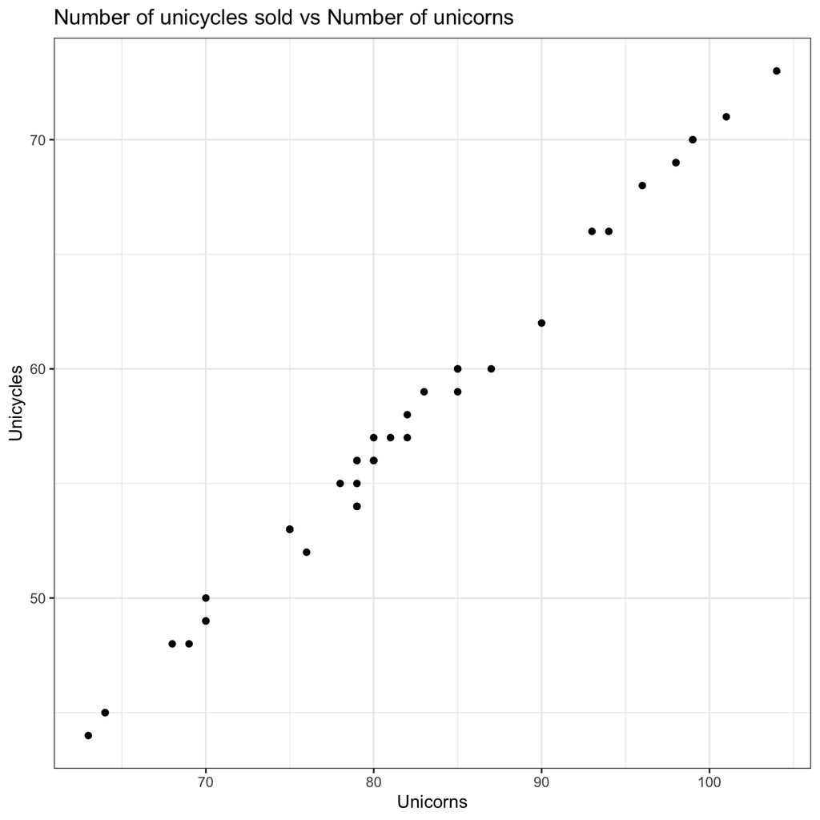

```r
#Dsiplaying ggplot with layers
 ggplot(data = unicorns.cycling,aes(x = pop, y = unicycles))+
  ggtitle("Number of unicycles sold vs Number of unicorns")+
  scale_x_continuous("Unicorns") +
   scale_y_continuous("Unicycles")+geom_point() + theme_bw()
```

```r
#I don't like it, I prefer using base R but, will try to get used to it.
```

# Problem 2: [50 pts] More Practice with EDA and Data Wrangling.

The data comes from Marvel Wikia and DC Wikia.

The data is split into two files, for DC and Marvel, respectively: `dc-wikia-data.csv` and `marvel-wikia-data.csv`.

[output not shown]

**Note:** These data sets have plenty of missing values so you will need to handle them appropriately depending on the situation.

1. Let’s do some very basic data cleaning. `FIRST APPEARANCE` is formatted differently in the two data sets. They both contain the month and year for first appearance. Additionally the variable `YEAR` contains the Year of first appearance (so there is a redundancy). Rename the `FIRST APPEARANCE` variable to `MONTH` and fix the observations so that they will be the Month given by the full word, i.e. March instead of Mar.

```r
#Additional tidyverse package
library(lubridate)
#Loading excel files
DC_Wikia <- read.csv("/Users/eduardosalvador/Desktop/FINAL\ Spring\ Semester\ 2021/CMDA\ /Assignments/HW5/dc-wikia-data.csv", header = T)
Marvel_Wikia <- read.csv("/Users/eduardosalvador/Desktop/FINAL\ Spring\ Semester\ 2021/CMDA\ /Assignments/HW5/marvel-wikia-data.csv", header = T)
#Renaming column 12 to MONTH
names(Marvel_Wikia)[12] <- "MONTH"
Marvel_Wikia$MONTH <- format(my(Marvel_Wikia$MONTH),"%B")
names(DC_Wikia)[12] <- "MONTH"
DC_Wikia$MONTH <- format(my(DC_Wikia$MONTH),"%B")
#Displaying headers
head(DC_Wikia)
```

|  | page_id | name | urlslug | ID | ALIGN | EYE | HAIR | SEX | GSM | ALIVE | APPEARANCES | MONTH | YEAR |
| --- | --- | --- | --- | --- | --- | --- | --- | --- | --- | --- | --- | --- | --- |
| 1 | 1422 | Batman (Bruce Wayne) | \\/wiki\\/Batman_(Bruce_Wayne) | Secret Identity | Good Characters | Blue Eyes | Black Hair | Male Characters |  | Living Characters | 3093 | NA | 1939 |
| 2 | 23387 | Superman (Clark Kent) | \\/wiki\\/Superman_(Clark_Kent) | Secret Identity | Good Characters | Blue Eyes | Black Hair | Male Characters |  | Living Characters | 2496 | NA | 1986 |
| 3 | 1458 | Green Lantern (Hal Jordan) | \\/wiki\\/Green_Lantern_(Hal_Jordan) | Secret Identity | Good Characters | Brown Eyes | Brown Hair | Male Characters |  | Living Characters | 1565 | NA | 1959 |
| 4 | 1659 | James Gordon (New Earth) | \\/wiki\\/James_Gordon_(New_Earth) | Public Identity | Good Characters | Brown Eyes | White Hair | Male Characters |  | Living Characters | 1316 | NA | 1987 |
| 5 | 1576 | Richard Grayson (New Earth) | \\/wiki\\/Richard_Grayson_(New_Earth) | Secret Identity | Good Characters | Blue Eyes | Black Hair | Male Characters |  | Living Characters | 1237 | NA | 1940 |
| 6 | 1448 | Wonder Woman (Diana Prince) | \\/wiki\\/Wonder_Woman_(Diana_Prince) | Public Identity | Good Characters | Blue Eyes | Black Hair | Female Characters |  | Living Characters | 1231 | NA | 1941 |

```r
head(Marvel_Wikia)
```

|  | page_id | name | urlslug | ID | ALIGN | EYE | HAIR | SEX | GSM | ALIVE | APPEARANCES | MONTH | YEAR |
| --- | --- | --- | --- | --- | --- | --- | --- | --- | --- | --- | --- | --- | --- |
| 1 | 1678 | Spider-Man (Peter Parker) | \\/Spider-Man_(Peter_Parker) | Secret Identity | Good Characters | Hazel Eyes | Brown Hair | Male Characters |  | Living Characters | 4043 | August | 1962 |
| 2 | 7139 | Captain America (Steven Rogers) | \\/Captain_America_(Steven_Rogers) | Public Identity | Good Characters | Blue Eyes | White Hair | Male Characters |  | Living Characters | 3360 | March | 1941 |
| 3 | 64786 | Wolverine (James \\"Logan\\" Howlett) | \\/Wolverine_(James_%22Logan%22_Howlett) | Public Identity | Neutral Characters | Blue Eyes | Black Hair | Male Characters |  | Living Characters | 3061 | October | 1974 |
| 4 | 1868 | Iron Man (Anthony \\"Tony\\" Stark) | \\/Iron_Man_(Anthony_%22Tony%22_Stark) | Public Identity | Good Characters | Blue Eyes | Black Hair | Male Characters |  | Living Characters | 2961 | March | 1963 |
| 5 | 2460 | Thor (Thor Odinson) | \\/Thor_(Thor_Odinson) | No Dual Identity | Good Characters | Blue Eyes | Blond Hair | Male Characters |  | Living Characters | 2258 | November | 1950 |
| 6 | 2458 | Benjamin Grimm (Earth-616) | \\/Benjamin_Grimm_(Earth-616) | Public Identity | Good Characters | Blue Eyes | No Hair | Male Characters |  | Living Characters | 2255 | November | 1961 |

2. Determine how many missing observations we have for each of the variables in the two data frames and display this in a table.

```r
#Showing hos many missing obsevations there are for DC and Marvel (is.na)
table(is.na(Marvel_Wikia))
```

```
 FALSE   TRUE
210162   2726
```

```r
table(is.na(DC_Wikia))
```

```
FALSE  TRUE
82328  7320
```

3. Has the proportion of Female Characters improved over time (in years)? Investigate this question using tables and plots for both DC and Marvel comics. Is DC or Marvel doing better with regards to Female Characters overall?

```r
#Marvel female character grouping by year
FMarvel <- Marvel_Wikia %>%
  group_by(YEAR) %>%
  summarize(proportion = sum(SEX == "Female Characters"))
  FMarvel
```

| YEAR | proportion |
| --- | --- |
| 1939 | 10 |
| 1940 | 33 |
| 1941 | 15 |
| 1942 | 14 |
| 1943 | 13 |
| 1944 | 12 |
| 1945 | 12 |
| 1946 | 12 |
| 1947 | 13 |
| 1948 | 14 |

[output cut: 66 more lines]

```r
#DC females grouped by year
FDC <- DC_Wikia %>%
  group_by(YEAR) %>%
  summarize(proportion = sum(SEX == "Female Characters"))
  FDC
```

| YEAR | proportion |
| --- | --- |
| 1935 | 0 |
| 1936 | 2 |
| 1937 | 1 |
| 1938 | 1 |
| 1939 | 5 |
| 1940 | 11 |
| 1941 | 8 |
| 1942 | 5 |
| 1943 | 0 |
| 1944 | 3 |

[output cut: 70 more lines]

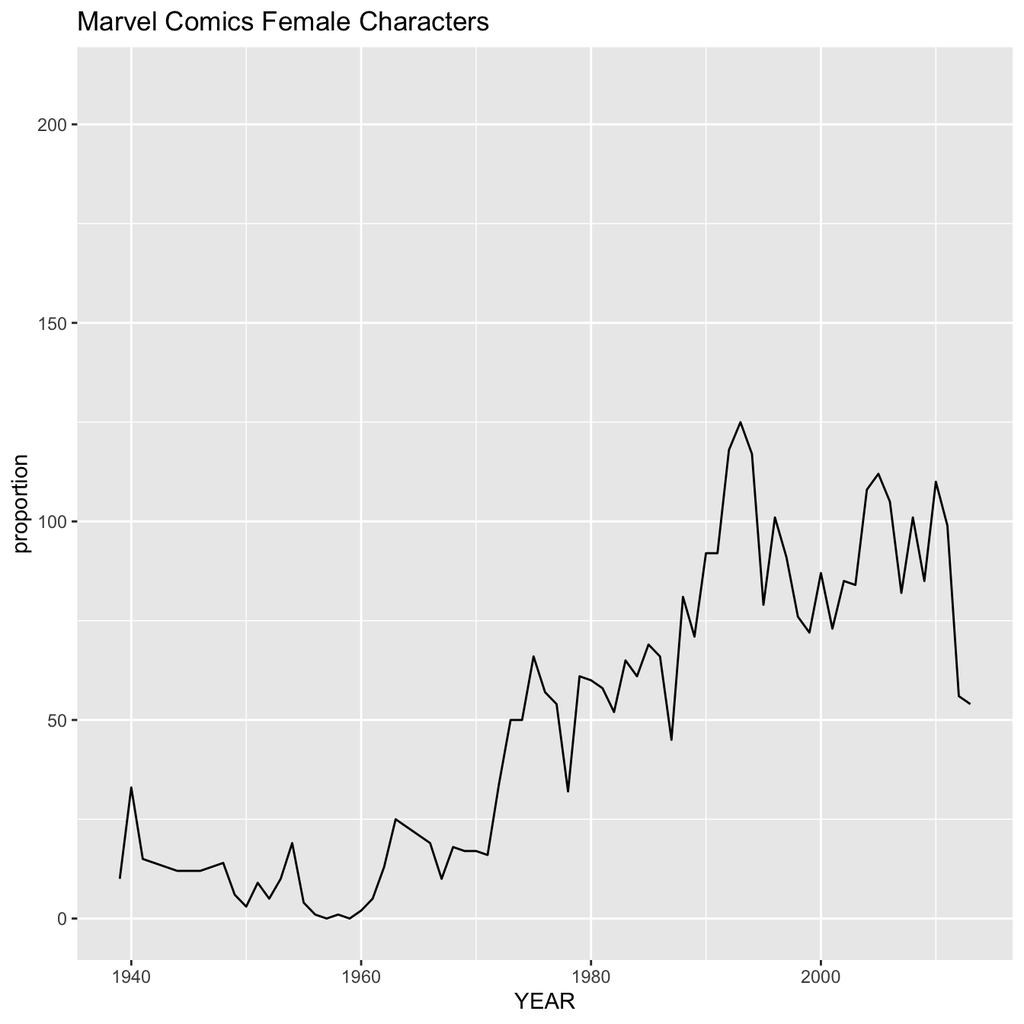

```r
#Displaying Marvel females character
ggplot(FMarvel) + geom_line(aes(x=YEAR,y=proportion)) + ggtitle("Marvel Comics Female Characters")
```